# Иллюстрации к статье

Вадим Хайтов

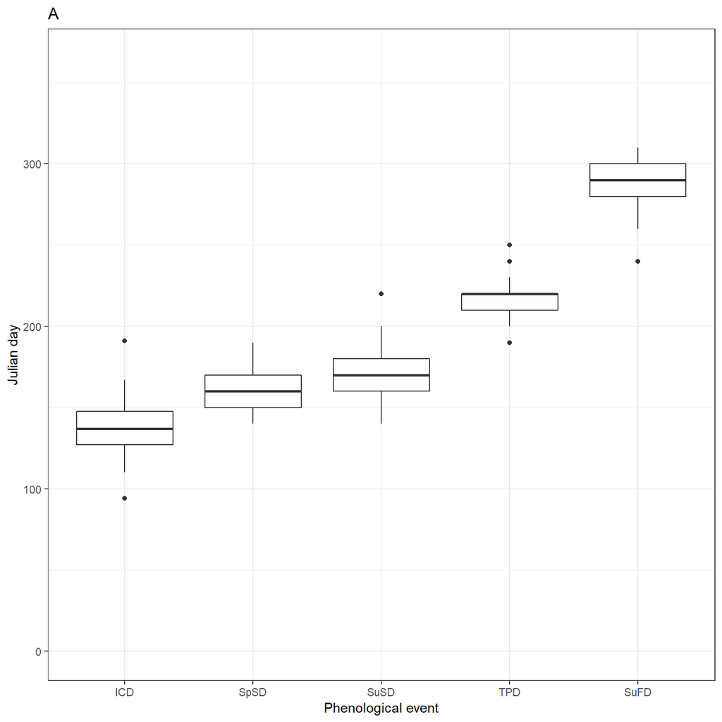

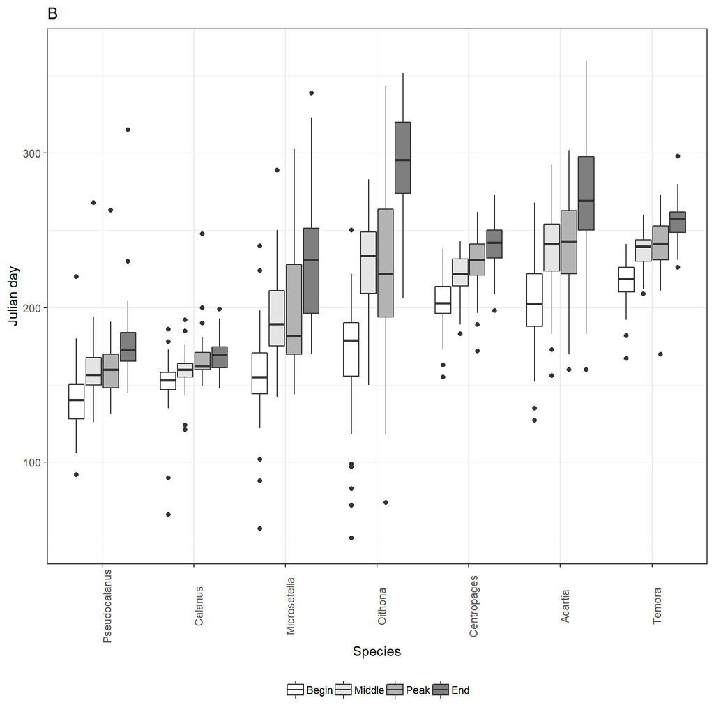

Fig. 3. Distribution of values of the key events taking place in the environment (A) and in the life cycles of the studied species (B). ICD – Ice clear date; SpSD – Spring start date (the day when the water temperature overcomes 3°C); SuSD – Summer start date (the day when the water temperature overcomes 5 Celsium degrees); TPD – The date when the highest water temperature was observed; SuFD – The date of summer end. Horizontal line refers to median. The box margin refers to the first quartile (lower) and third quartile (upper), i.e. the 25th and 75th percentiles. Vertical lines refer to 1.5 IQR (inter-quartile range, or distance between the first and third quartiles).

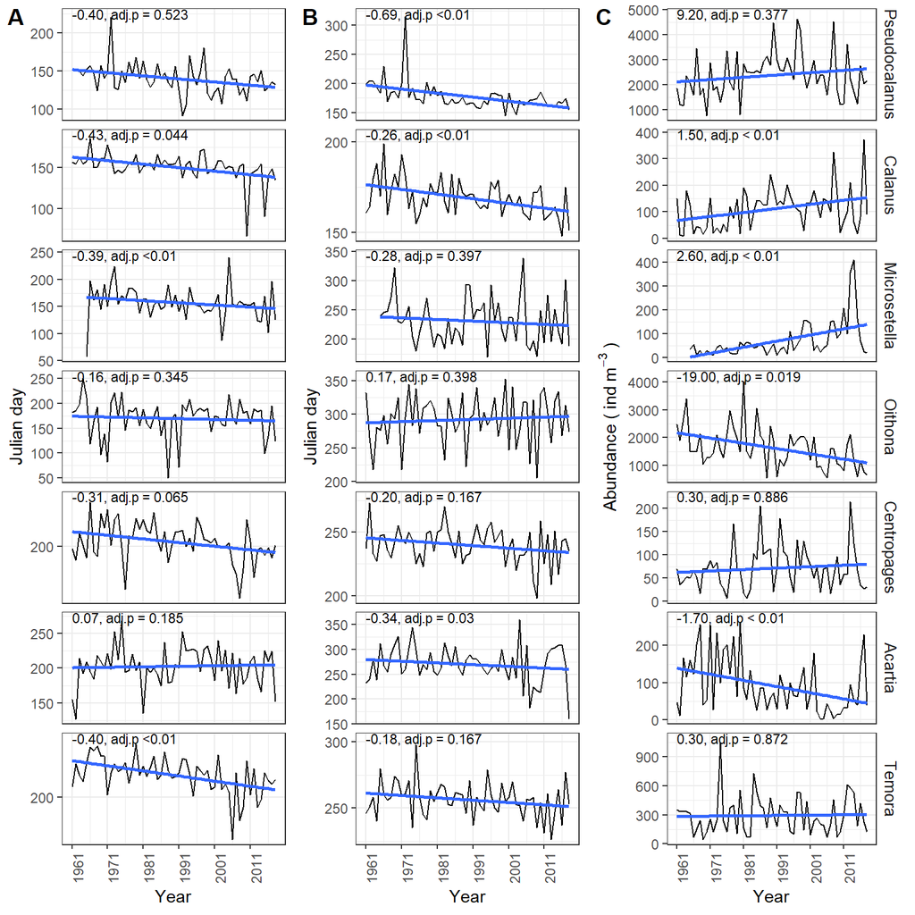

Fig. 4. Long-term changes in the timing of phenological events (beginning-of-season (A) and end-of-season (B)) in the seasonal dynamics of the studied species, and the dynamics of the total numbers of their populations in the layer 0-65 m (C). Abundance is given as ind./m3. The straight line represents the linear model connecting phenologucal indices and abundance with time. Numbers above the regression line are the slope coefficient of the model and the level of significance for the Mantel correlation (see Materials and Methods for details).

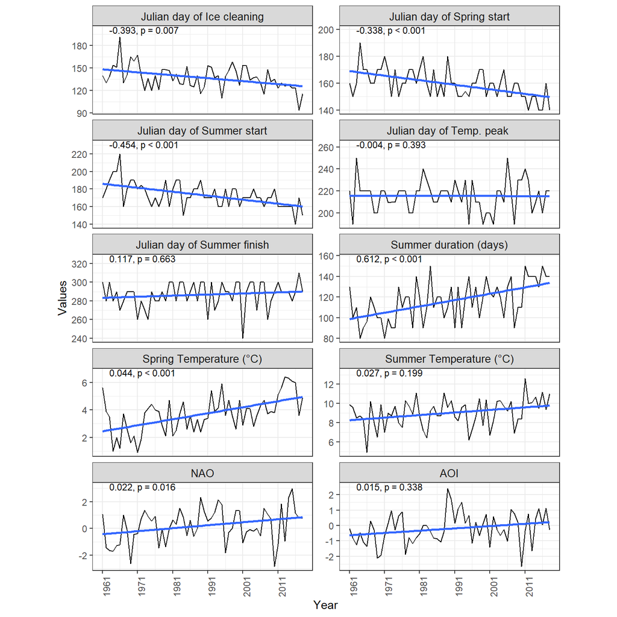

Fig. 5. Long-term changes in the timing of seasonal events in the environment. TPD – Julian day when temperature maximum was observed; SpSD – Julian day when hydrological spring started (water temperature reached 3°C); SuSD – Julian day when hydrological summer started (water temperature reached 5°C); SuFD – Julian day when hydrological summer ends; SuDur – summer duration; ICD – Julian day when ice clearing was observed; SpT – Mean spring temperature; SuT – Mean summer temperature; NAO – North Atlantic oscillation index; AOI – Arctic oscillation index. Meaning of lines and numbers – see Fig. 4.

## Результаты ССА

Table +. Permutation significance test of the CCA model

| Term | df | Chi sq. | pseudo F | p |
| --- | --- | --- | --- | --- |
| **Whole model** |  |  |  |  |
| Model | 18 | 0.0052 | 1.3 | 0.020 |
| Residual | 35 | 0.0075 |  |  |
| **Constrined axis** |  |  |  |  |
| CCA1 | 1 | 0.0018 | 8.6 | 0.025 |
| Residual | 35 | 0.0075 |  |  |
| **Predictors** |  |  |  |  |
| SuFDPY | 1 | 0.0006 | 2.7 | 0.011 |
| Acartia_N | 1 | 0.0004 | 2.1 | 0.038 |
| Microsetella_N | 1 | 0.0005 | 2.5 | 0.018 |
| Residual | 35 | 0.0075 |  |  |

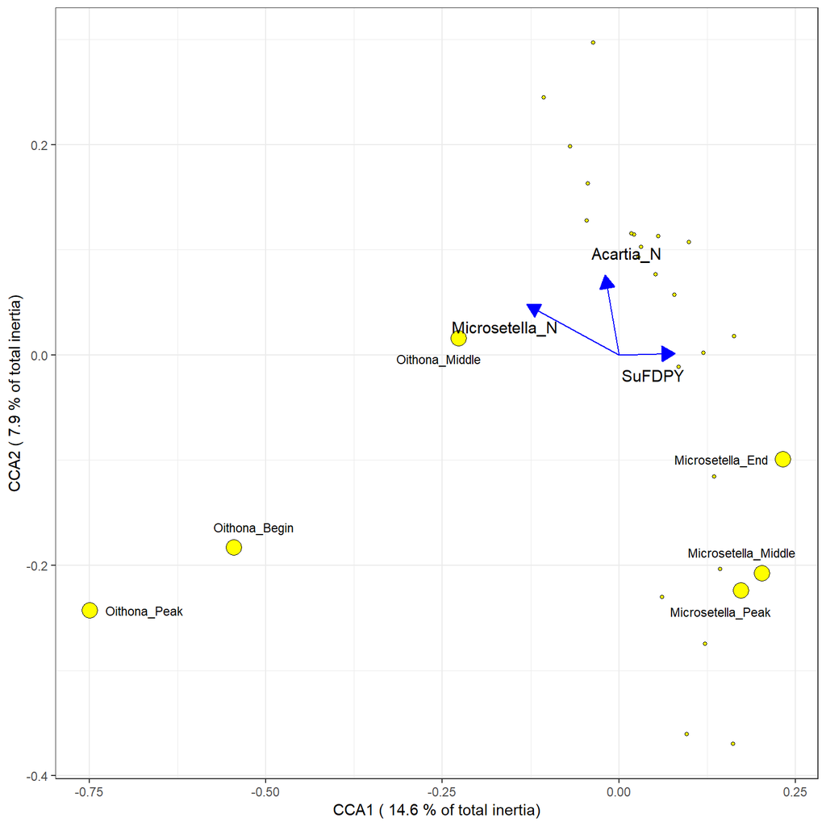

Fig. 6. Ordination of phenological characteristics of species in constrained axes of CCA. Large points correspond to the phenological indicators that have absolute values on the first axis outside the 2-nd quartile. The arrows indicate the significant predictors included in the model.

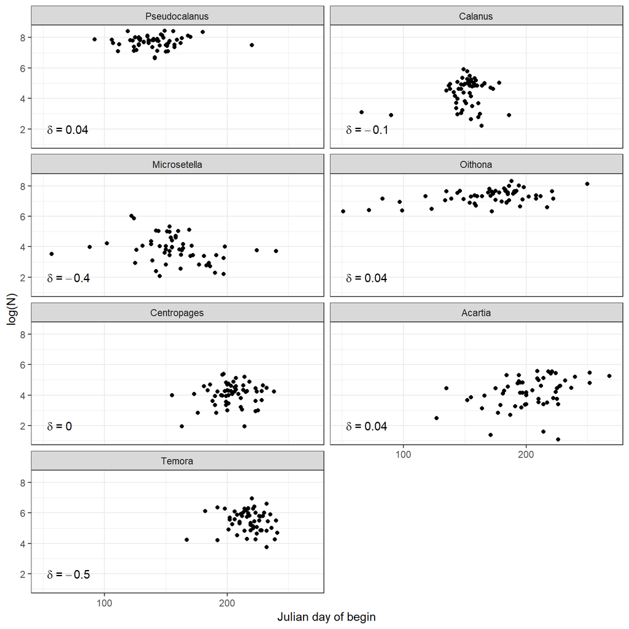

Fig. 5. The relationship between the abundance of the species (Log(N+1)) in a given year and the beginning-of-season. Each point corresponds to one year of observations. The number on each graph indicates the correlation between dynamics of abundance and the start of season (see Material and Methods for details about correlaton assessment).

Вместо рисунка можно привести такую таблицу

| Species | Correlation |
| --- | --- |
| Pseudocalanus | 0.04 |
| Calanus | -0.11 |
| Oithona | 0.04 |
| Centropages | 0.00 |
| Acartia | 0.04 |
| Temora | -0.50 |
| Microsetella | -0.42 |